# Building Ig clones

2023-09-01

## Overview

For the T cells the clonotype labels have already been created by joining the V, J and CDR3AA sequence.

This workflow uses the [IMGT CDR3 definition](https://www.imgt.org/IMGTScientificChart/Numbering/IMGTIGVLsuperfamily.html) which excludes the 104-Cys and 118-Phe/Tyr. There are other CDR3 definitions that incorporate these residues. The equivalent ‘CDR3’ can be obtained from the `junction` and `junction_aa` columns reported by `IgBLAST` which will include the anchor residues.

As the B cell chains undergo somatic hypermutation (SHM) we need to use a method for defining clonal groups that permits grouping of similar but not exact sequences. Hierarchical clustering of the Ig sequences CDR3 sequence is one approach used to identify groups of cells that carry sequences that may be derived from the same original progenitor B cell but which have diverged over time due to SHM.

Clustering must be undertaken for each individual as a clonal lineage can only exist within a single person. Similar Igs from different individuals are ‘convergent’, similar Abs in different individuals that may have arisen from response to the same antigen, rather than ‘divergent’ members of the same clone. The same type of clustering can be used to explore convergence (also known as public clones) in antibody responses but this is in addition to building clonal lineages within an individual’s immune response.

In the example datasets the PMBC and tumour samples are from different individuals so clones will be built separately. If a 10x dataset includes multiple samples from different individuals that require de-multiplexing via hashing antibodies or SNPs then the B cell V(D)J data must be subset for the different individuals before building clones.

An excellent resource for post-processing of 10x data including building clonal relationships can be found at on the [Immcantation framework site](https://immcantation.readthedocs.io/en/stable/tutorials/10x_tutorial.html). It provides an approach that can be undertaken in R. You can use alternative tools such as [cd-hit](https://github.com/weizhongli/cdhit) outside of R but this requires some additional coding to wrangle the `cd-hit` output into a format that can be joined to the `Cell Ranger` and `IgBLAST` cell barcode level information.

The R markdown script for this workflow available on [github](https://raw.githubusercontent.com/kjlj/scRNA-seq_VDJ/main/docs/building_b_cell_clones.Rmd) in the [workshop respository](https://github.com/kjlj/scRNA-seq_VDJ).

Here, we build upon the Ig data generated from the [combining IgBLAST and cellranger workflow](https://kjlj.github.io/scRNA-seq_VDJ/docs/joining_cellranger_igblast.html).

## Setting up R session

### Working locally versus working on Posit Cloud

If working locally it may be of benefit to set the working directory at the start of your R session so that you can use relative file paths, this isn’t required when using RStudio on Posit Cloud.

Uncomment set working directory function and update the path to the location of your choice:

```r
#setwd("~/Documents/GitHub/scRNA-seq_VDJ/")
```

### R packages

The [tidyverse collection](https://www.tidyverse.org/) of R packages will be used to manipulate the datasets.

Install this package (if it is not already available) and then load it into the R session:

```r
#check if the package is already installed, if not, install it
if (sum(grepl("tidyverse", rownames(installed.packages()))) > 0) {
  print("tidyverse is already installed")
} else {
  install.packages("tidyverse")
}
```

```
## [1] "tidyverse is already installed"
```

```r
#loading R packages
library(tidyverse)
```

To undertake the clone clustering requires two packages from the [Immcantation framework](https://immcantation.readthedocs.io/en/stable/); [SCOPer](https://scoper.readthedocs.io/en/stable/) and [SHazaM](https://shazam.readthedocs.io/en/stable/).

Install these (if not already available) and load them into the R session:

```r
#check if the package is already installed, if not, install it
if (sum(grepl("scoper", rownames(installed.packages()))) > 0) {
  print("SCOPer is already installed")
} else {
  install.packages("scoper")
}
```

```
## [1] "SCOPer is already installed"
```

```r
if (sum(grepl("shazam", rownames(installed.packages()))) > 0) {
  print("SHazaM is already installed")
} else {
  install.packages("shazam")
}
```

```
## [1] "SHazaM is already installed"
```

```r
#loading R packages
library(scoper)
library(shazam)
```

### Themes for ggplot2

Adding some custom ggplot2 themes for plotting:

```r
##themes for plots
theme_custom <- function (base_size = 12) {
  theme_bw(base_size=base_size) %+replace%
    theme(panel.grid = element_blank(),
          panel.border = element_blank(),
          axis.line = element_line(colour="black"),
          axis.text.x = element_text(colour="black", size=base_size),
          axis.text.y = element_text(colour="black", size = base_size, hjust = 1),
          axis.title = element_text(colour="black", face="bold", size = base_size),
          strip.background = element_blank(),
          strip.text = element_text(colour="black", face="bold", size=base_size),
          legend.text = element_text(colour="black", size=base_size)
    )
}

theme_x_rotated <- function (base_size = 12) {
  theme_custom(base_size=base_size) %+replace%
    theme(axis.text.x = element_text(colour="black", angle = 90, hjust = 1, vjust = 0.5, size=base_size))
}
```

## Datasets

This workflow uses the Ig dataset that was output from [previous workflow](https://kjlj.github.io/scRNA-seq_VDJ/docs/joining_cellranger_igblast.html). The tab-delimited output file (pbmc-tumour_Ig_cellranger_igblast_per-barcode.tsv) that contains the Ig VDJ data for the PBMC and tumour datasets is hosted on the [github repository](https://github.com/kjlj/scRNA-seq_VDJ).

The data will be loaded from the githib repo, but can alternatively be loaded locally by changing to a file path within the `read_tsv()` function:

```r
#loading the B cell post-processed data
bcr.data <- read_tsv("https://raw.githubusercontent.com/kjlj/scRNA-seq_VDJ/main/data/pbmc-tumour_Ig_cellranger_igblast_per-barcode.tsv")
table(bcr.data$dataset)
```

```
##
##   pbmc tumour
##    982   5644
```

As clones are defined within a single individual, the PBMC and tumour VDJs need to be separated:

```r
#split into tumour and pbmc
pbmc.data <- bcr.data %>% filter(dataset == "pbmc")
tumour.data <- bcr.data %>% filter(dataset == "tumour")

#check the number of cells in each after the split
pbmc.data %>% nrow()
```

```
## [1] 982
```

```r
tumour.data %>% nrow()
```

```
## [1] 5644
```

## Set the clustering threshold

Before performing the hierarchical clustering the threshold needs to be defined. This is done by comparing the pairwise [hamming distance](https://en.wikipedia.org/wiki/Hamming_distance) between sequences in a dataset to find each sequence’s hamming distance to its nearest neighbour (the sequence with the lowest hamming distance). This should result in a bimodal distribution that defines ‘clones’ (sequences very near to each other) and ‘unrelated’ (sequences more distant from each other).

For this, we can use the IGH data.

The `SHazaM` package expects `IgBLAST` column names in their original format so we need to extract those columns and rename them to remove the `_iglbast_igh` suffix that we appended previously:

```r
## the shazam package uses the IgBLAST columns, so can just select those and rename appropriately
pbmc.igh.data <- pbmc.data %>%
  select(barcode, sequence_id = contig_id_igh, ends_with("_igblast_igh")) %>%
  rename_with(~ str_replace(.x, "_igblast_igh", ""), everything()) %>%
  filter(!(is.na(cdr3))) #need to remove any unpaired entries as they will cause errors

tumour.igh.data <- tumour.data %>%
  select(barcode, sequence_id = contig_id_igh, ends_with("_igblast_igh")) %>%
  rename_with(~ str_replace(.x, "_igblast_igh", ""), everything()) %>%
  filter(!(is.na(cdr3))) #need to remove any unpaired entries as they will cause errors
```

Check that the column names are as expected:

```r
pbmc.igh.data %>% glimpse()
```

```
## Rows: 966
## Columns: 112
## $ barcode                 <chr> "AAACCTGTCCGTTGTC-1", "AAACCTGTCGAGAACG-1", "A…
## $ sequence_id             <chr> "AAACCTGTCCGTTGTC-1_contig_2", "AAACCTGTCGAGAA…
## $ sequence                <chr> "ATCACATAACAACCACATTCCTCCTCTAAAGAAGCCCCTGGGAGC…
## $ sequence_aa             <chr> "QVQLVQSGAEVKKPGSSVKVSCKASGGTFSSYAISWVRQAPGQGL…
## $ locus                   <chr> "IGH", "IGH", "IGH", "IGH", "IGH", "IGH", "IGH…
## $ stop_codon              <lgl> FALSE, FALSE, FALSE, FALSE, FALSE, FALSE, FALS…
## $ vj_in_frame             <lgl> TRUE, TRUE, TRUE, TRUE, TRUE, TRUE, TRUE, TRUE…
## $ v_frameshift            <lgl> FALSE, FALSE, FALSE, FALSE, FALSE, FALSE, FALS…
## $ productive              <lgl> TRUE, TRUE, TRUE, TRUE, TRUE, TRUE, TRUE, TRUE…
## $ rev_comp                <lgl> FALSE, FALSE, FALSE, FALSE, FALSE, FALSE, FALS…
## $ complete_vdj            <lgl> TRUE, TRUE, TRUE, TRUE, TRUE, TRUE, TRUE, TRUE…
## $ d_frame                 <lgl> NA, NA, NA, NA, NA, NA, NA, NA, NA, NA, NA, NA…
## $ v_call                  <chr> "IGHV1-69*01,IGHV1-69D*01", "IGHV1-2*02", "IGH…
```

[output cut: 99 more lines]

For each sequence, add the hamming distance to its nearest neighbour using the `distToNearest()` function:

```r
#add the distance to the nearest other heavy chain in the dataset to the tibbles
pbmc.igh.data <- distToNearest(pbmc.igh.data, nproc = 1)
tumour.igh.data <- distToNearest(tumour.igh.data, nproc = 1)

#summarise the dists from the PBMC
summary(pbmc.igh.data$dist_nearest)
```

```
##    Min. 1st Qu.  Median    Mean 3rd Qu.    Max.    NA's
##  0.0625  0.3529  0.3939  0.4000  0.4500  0.6842     484
```

Plot the distances to look for the valley between the bimodal distribution that should provide a threshold between ‘clonal’ and ‘unrelated’ sequences:

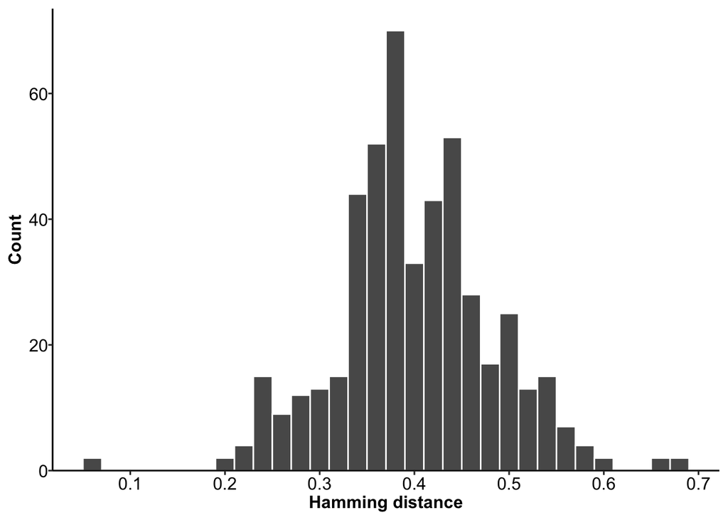

```r
#plotting the distribution
pbmc.dist.p1 <- ggplot(pbmc.igh.data %>% filter(!is.na(dist_nearest)),
             aes(x = dist_nearest)) +
  theme_bw() +
  xlab("Hamming distance") + ylab("Count") +
  scale_x_continuous(breaks = seq(0, 1, 0.1)) +
  geom_histogram(color = "white", binwidth = 0.02) +
  scale_y_continuous(expand = expansion(mult = c(0, 0.05))) +
  theme_custom()
plot(pbmc.dist.p1)
```

There don’t appear to be many clonally related sequences in the PBMC dataset, but a threshold of 0.1 should split the ‘clones’ from the ‘unrelated’ sequences:

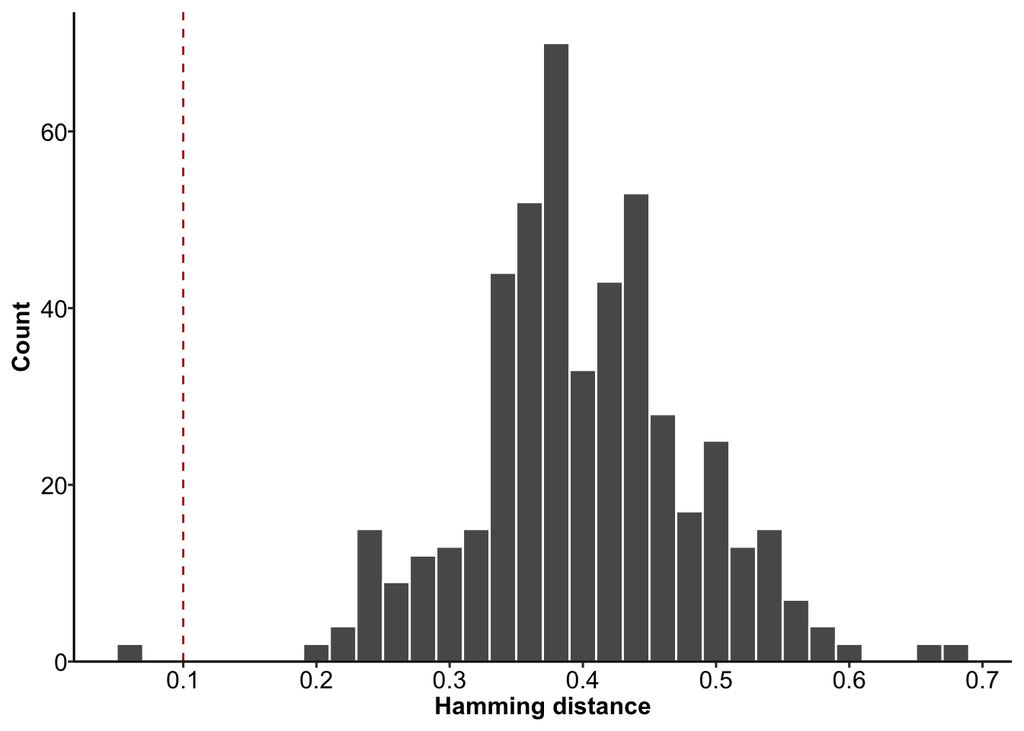

```r
#add a line for threshold
pbmc.dist.p1 <- pbmc.dist.p1 +
  geom_vline(xintercept = 0.1, linetype = "dashed", colour = "firebrick")
plot(pbmc.dist.p1)
```

Repeat the process for the IGH from the tumour dataset:

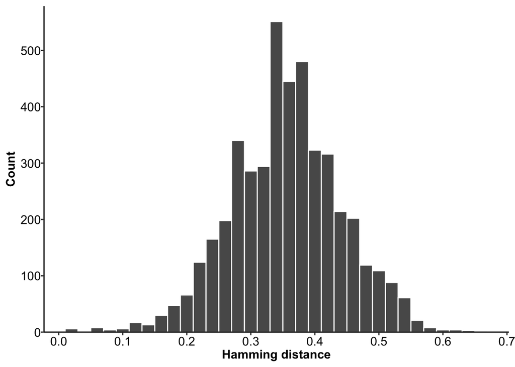

```r
#plotting distribution for the tumour sample
tumour.dist.p1 <- ggplot(tumour.igh.data %>% filter(!is.na(dist_nearest)),
                       aes(x = dist_nearest)) +
  theme_bw() +
  xlab("Hamming distance") + ylab("Count") +
  scale_x_continuous(breaks = seq(0, 1, 0.1)) +
  geom_histogram(color = "white", binwidth = 0.02) +
  scale_y_continuous(expand = expansion(mult = c(0, 0.05))) +
  theme_custom()
plot(tumour.dist.p1)
```

For the tumour IGH dataset the ‘valley’ is less defined, but 0.1 looks acceptable:

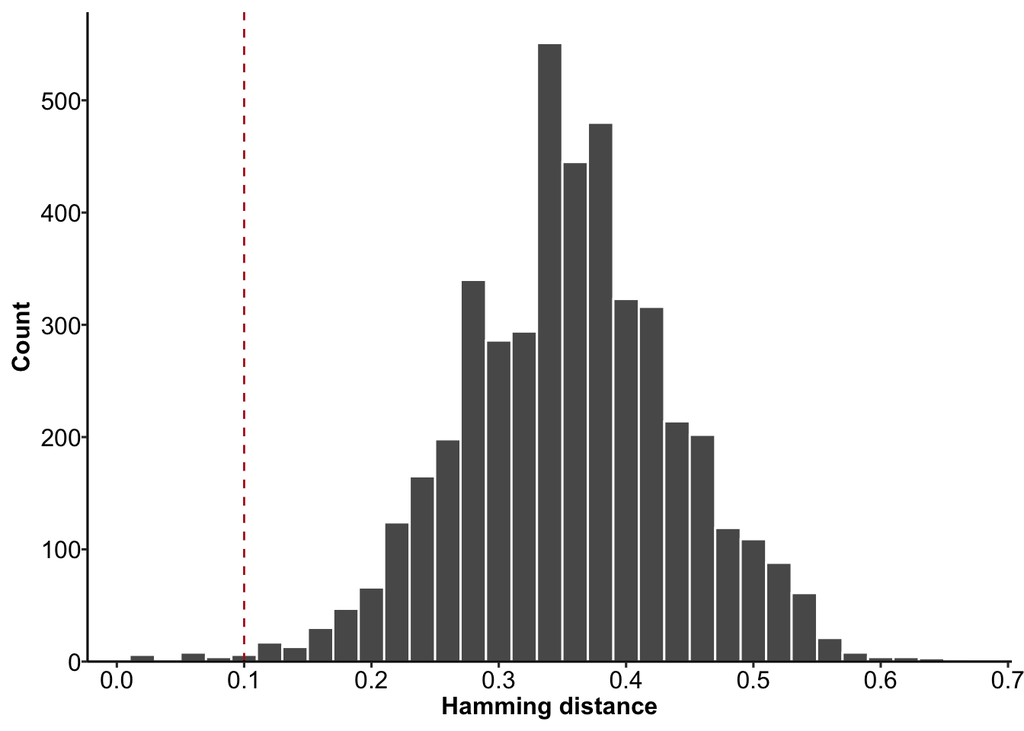

```r
#add a line for threshold
tumour.dist.p1 <- tumour.dist.p1 +
  geom_vline(xintercept = 0.1, linetype = "dashed", colour = "firebrick")
plot(tumour.dist.p1)
```

Opting to use a threshold of 0.1 for both datasets, save this to the threshold variable:

```r
#looks like 0.1 would be suitable threshold for both samples
threshold <- 0.1
```

[output not shown]

## Building the clones within each dataset

To run the `SCOPer` clone building in ‘single-cell’ mode we need to reformat the tibble to have the igh and igkl for each cell barcode as separate rows:

```r
pbmc.igkl.data <- pbmc.data %>%
  select(barcode, sequence_id = contig_id_igkl, ends_with("_igblast_igkl")) %>%
  rename_with(~ str_replace(.x, "_igblast_igkl", ""), everything()) %>%
  filter(!(is.na(cdr3))) #need to remove any unpaired entries as they will cause errors

tumour.igkl.data <- tumour.data %>%
  select(barcode, sequence_id = contig_id_igkl, ends_with("_igblast_igkl")) %>%
  rename_with(~ str_replace(.x, "_igblast_igkl", ""), everything()) %>%
  filter(!(is.na(cdr3))) #need to remove any unpaired entries as they will cause errors

#combine the igh and igkl from each together to a single tibble
pbmc.input <- bind_rows(pbmc.igh.data, pbmc.igkl.data)
tumour.input <- bind_rows(tumour.igh.data, tumour.igkl.data )
```

These tibbles will now have two entries for any cell barcodes that had paired chains or a single entry for cell barcode that only had a single chain:

```r
pbmc.input %>% glimpse()
```

```
## Rows: 1,941
## Columns: 113
## $ barcode                 <chr> "AAACCTGTCCGTTGTC-1", "AAACCTGTCGAGAACG-1", "A…
## $ sequence_id             <chr> "AAACCTGTCCGTTGTC-1_contig_2", "AAACCTGTCGAGAA…
## $ sequence                <chr> "ATCACATAACAACCACATTCCTCCTCTAAAGAAGCCCCTGGGAGC…
## $ sequence_aa             <chr> "QVQLVQSGAEVKKPGSSVKVSCKASGGTFSSYAISWVRQAPGQGL…
## $ locus                   <chr> "IGH", "IGH", "IGH", "IGH", "IGH", "IGH", "IGH…
## $ stop_codon              <lgl> FALSE, FALSE, FALSE, FALSE, FALSE, FALSE, FALS…
## $ vj_in_frame             <lgl> TRUE, TRUE, TRUE, TRUE, TRUE, TRUE, TRUE, TRUE…
## $ v_frameshift            <lgl> FALSE, FALSE, FALSE, FALSE, FALSE, FALSE, FALS…
## $ productive              <lgl> TRUE, TRUE, TRUE, TRUE, TRUE, TRUE, TRUE, TRUE…
## $ rev_comp                <lgl> FALSE, FALSE, FALSE, FALSE, FALSE, FALSE, FALS…
## $ complete_vdj            <lgl> TRUE, TRUE, TRUE, TRUE, TRUE, TRUE, TRUE, TRUE…
## $ d_frame                 <lgl> NA, NA, NA, NA, NA, NA, NA, NA, NA, NA, NA, NA…
## $ v_call                  <chr> "IGHV1-69*01,IGHV1-69D*01", "IGHV1-2*02", "IGH…
```

[output cut: 100 more lines]

The clones will be generated using the `hierarchicalClones()` function from the `SCOPer` package. This function will add a ‘clone_id’ column to the tibble and entries that share the same ‘clone_id’ are considered members of the same clonal lineage:

```r
#add the clone id columns for PBMC
pbmc.input <- hierarchicalClones(pbmc.input,
                              threshold = threshold,
                              cell_id = "barcode",
                              method = "nt",
                              linkage = "average",
                              junction = "cdr3",
                              only_heavy = FALSE,
                              split_light = TRUE,
                              summarize_clones = FALSE)
```

```
## Running defineClonesScoper in single cell mode
```

```r
#add the clone id columns for tumour
tumour.input <- hierarchicalClones(tumour.input,
                                   threshold = threshold,
                                   cell_id = "barcode",
                                   method = "nt",
                                   linkage = "average",
                                   junction = "cdr3",
                                   only_heavy = FALSE,
                                   split_light = TRUE,
                                   summarize_clones = FALSE)
```

```
## Running defineClonesScoper in single cell mode
```

Extract the clone IDs so that they can be added to the original tibble that summarises the `IgBLAST` and `Cell Ranger` data for each cell barcode:

```r
#extract the clone_id and add back to the main tibble
pbmc.clns <- pbmc.input %>%
  select(barcode, clone_id) %>%
  unique() %>% #as data is formatted as IGH and IGK/L as separate entries the barcode + clone_id is duplicated for IGH and IGK/l
  mutate(dataset = "pbmc")

tumour.clns <- tumour.input %>%
  select(barcode, clone_id) %>%
  unique() %>%
  mutate(dataset = "tumour")

#combine the pbmc & tumour clone IDs
cln.data <- bind_rows(pbmc.clns, tumour.clns)

cln.data %>% head()
```

```
## # A tibble: 6 × 3
##   barcode            clone_id dataset
##   <chr>              <chr>    <chr>
## 1 AGCTCTCTCCGAGCCA-1 1        pbmc
## 2 GACTACAGTCCAGTGC-1 2        pbmc
## 3 TTCTACACAGGATTGG-1 3        pbmc
## 4 GCAAACTGTTGAACTC-1 4        pbmc
## 5 TATCTCAGTCTGGAGA-1 5        pbmc
## 6 CTCGTACTCAACGGGA-1 6        pbmc
```

Merge the BCR data that we originally loaded with the clone ID labels:

```r
#joining the clone_ids by barcode & dataset
bcr.cln.data <- bcr.data %>%
  left_join(cln.data, by = c("barcode", "dataset"))

#check that the number of rows match
bcr.data %>% nrow() == bcr.cln.data %>% nrow()
```

```
## [1] TRUE
```

As PBMC and tumour data are in same tibble, the clone_ids are not unique as the same ‘clone_id’ can be in both datasets. To avoid possible issues during analysis, create a unique clone ID by combining the ‘dataset’ and ‘clone_id’ values together in a new label:

```r
#add a unique labels for the clns that is the clone_id + dataset
bcr.cln.data <- bcr.cln.data %>%
  mutate(unq_clone_id = ifelse(is.na(clone_id), NA_character_, paste(dataset, clone_id, sep = "_")))
```

Finally, create a quick summary of clone sizes to check if there are any expanded clones:

```r
#quick summary of clone sizes
cln.size.summary <- bcr.cln.data %>%
  filter(!(is.na(unq_clone_id))) %>% #remove cells that lack a clone call
  group_by(dataset, unq_clone_id) %>% #group by clone_id & dataset
  summarise(cln_size = length(barcode)) %>% #count the number of barcodes in each clones
  ungroup() %>% #remove the grouping
  arrange(desc(cln_size)) #reorder the data from largest to smallest clone size across the two datasets
cln.size.summary
```

```
## # A tibble: 6,220 × 3
##    dataset unq_clone_id cln_size
##    <chr>   <chr>           <int>
##  1 tumour  tumour_5111         7
##  2 tumour  tumour_532          6
##  3 tumour  tumour_1601         4
##  4 tumour  tumour_1725         4
##  5 tumour  tumour_237          4
##  6 tumour  tumour_2519         4
##  7 tumour  tumour_3515         4
##  8 tumour  tumour_3874         4
##  9 tumour  tumour_4217         4
## 10 tumour  tumour_4496         4
## # ℹ 6,210 more rows
```

## Outputting datasets

Write the BCR data that now includes the clone ID information to a new tab-delimited file:

```r
write_tsv(bcr.cln.data, "~/Documents/GitHub/scRNA-seq_VDJ/data/pbmc-tumour_Ig_cellranger_igblast_per-barcode_clns.tsv")
```

## Next step

Now move to [integrating VDJ with scRNA-seq data](https://kjlj.github.io/scRNA-seq_VDJ/docs/combining_GEX_and_VDJ.html).

Go back to [merging cell ranger and IgBLAST data](https://kjlj.github.io/scRNA-seq_VDJ/docs/joining_cellranger_igblast.html).

Or [retrun to main page](https://kjlj.github.io/scRNA-seq_VDJ/)